[figure not shown]

# Relatório 07

Kaleb Aquino Mileib”

29/04/2025

# 1 Objetivo

O objetivo deste relatório é investigar a adequação do modelo de análise de variância (ANAVA) tradicional frente às pressuposições estatísticas fundamentais para sua validade, com foco na análise de resíduos. A ANAVA pressupõe que os erros (ou resíduos) do modelo sejam normalmente distribuídos, com variâncias homogêneas entre os grupos (homocedasticidade) e independentes. Quando essas suposições não são atendidas, os resultados do teste F podem ser enganosos, levando a interpretações equivocadas sobre a significância dos fatores estudados. Assim, este trabalho busca aplicar ferramentas diagnósticas gráficas e testes formais para avaliar essas suposições e, diante de violações, propor soluções metodológicas adequadas.

Para ilustrar essas situações, é apresentado um experimento simulado utilizando dados artificiais com características específicas, como a presença de valores extremos (outliers), que intencionalmente comprometem a normalidade e a homocedasticidade dos resíduos. O objetivo é demonstrar como a análise de resíduos pode evidenciar esses problemas e como estratégias corretivas - como transformações nos dados ou o uso de métodos não paramétricos, como o teste de Kruskal-Wallis - podem ser aplicadas de forma eficaz. O relatório visa, portanto, reforçar a importância da validação dos pressupostos da ANAVA como etapa essencial na análise de experimentos, garantindo que as conclusões estatísticas sejam confiáveis e representem com precisão os fenômenos investigados.

# 2 Desenvolvimento

## 2.1 Descrição do Experimento Simulado

Neste estudo, simulamos um experimento com o objetivo de comparar a eficácia de três métodos de controle automático (PID, LQR e Fuzzy) aplicados a um sistema térmico. A variável de interesse é o **tempo de estabilização** do sistema, medido em segundos, que representa o tempo necessário para o sistema atingir um estado estacionário após uma perturbação. Cada método de controle é avaliado com **10 réplicas**, totalizando 30 observações no experimento. O fator experimental é o **Tipo de Controle**, com três níveis: PID, LQR e Fuzzy.

Para fins didáticos e de investigação estatística, foi introduzida uma situação anômala no grupo Fuzzy: **três observações com valores extremamente altos (25, 28 e 30 segundos)** foram incluídas intencionalmente. Esses valores são **outliers graves**, muito distantes da média esperada do grupo. O objetivo é analisar o impacto desses outliers nas pressuposições da ANAVA tradicional, em especial a **normalidade dos resíduos e a homogeneidade das variâncias**, e propor soluções adequadas quando essas condições são violadas. A análise será conduzida com ferramentas gráficas e testes formais, seguida de uma abordagem alternativa baseada em métodos não paramétricos.

```r
# Carregar bibliotecas
library(gt)
library(dplyr)
# Gerar os dados
set.seed(456)
Controle <- rep(c("PID", "LQR", "Fuzzy"), each = 10)

Tempo <- c(
  rnorm(10, mean = 10, sd = 0.5),        # PID
  rnorm(10, mean = 9, sd = 0.6),         # LQR
  c(rnorm(7, mean = 11, sd = 0.4), 25, 30, 28)  # Fuzzy com outliers
)

dados <- data.frame(Controle, Tempo)

# Exibir tabela formatada
dados |>
  gt() |>
  tab_style(
    style = list(cell_text(weight = "bold", color = "white"),
                 cell_fill(color = "black")),
    locations = cells_column_labels()
  ) |>
  tab_style(
    style = cell_text(align = "center"),
    locations = cells_body(columns = everything())
  ) |>
  data_color(
    columns = everything(),
    rows = seq(1, 10, 1),
    palette = "#f2f2f2"
  ) |>
  data_color(
    columns = everything(),
    rows = seq(11, 20, 1),
    palette = "#FFB2B2"
  ) |>
  data_color(
    columns = everything(),
    rows = seq(21, 30, 1),
    palette = "#f2f2f2"
  )
```

| Controle | Tempo |
| --- | --- |
| PID | 9.328239 |
| PID | 10.310888 |
| PID | 10.400437 |
| PID | 9.305554 |
| PID | 9.642822 |
| PID | 9.837969 |
| PID | 10.345321 |
| PID | 10.125274 |
| PID | 10.503676 |
| PID | 10.286617 |
| LQR | 8.450514 |
| LQR | 9.786658 |
| LQR | 9.593236 |
| LQR | 9.992357 |
| LQR | 8.135517 |
| LQR | 10.168414 |
| LQR | 10.042162 |
| LQR | 9.232490 |
| LQR | 10.368020 |
| LQR | 9.922730 |
| Fuzzy | 10.810158 |
| Fuzzy | 10.313076 |
| Fuzzy | 10.429268 |
| Fuzzy | 11.083294 |
| Fuzzy | 10.985666 |
| Fuzzy | 11.453714 |
| Fuzzy | 10.814858 |
| Fuzzy | 25.000000 |
| Fuzzy | 30.000000 |
| Fuzzy | 28.000000 |

## 2.2 Tabela ANOVA

A tabela de ANAVA apresentada mostra a comparação entre três métodos de controle automático (PID, LQR e Fuzzy), com a variável resposta sendo o tempo de estabilização. O valor de p (0,0101) é inferior ao nível de significância de 5%, o que indica que há uma diferença estatisticamente significativa entre pelo menos dois dos grupos analisados. Ou seja, rejeita-se a hipótese nula de igualdade das médias, sugerindo que o tipo de controle influencia o tempo de estabilização do processo térmico.

```r
modelo <- aov(Tempo ~ Controle, data = dados)
summary(modelo)
```

```
##             Df Sum Sq Mean Sq F value Pr(>F)
## Controle     2  249.0  124.52   5.468 0.0101 *
## Residuals   27  614.9   22.77
## ---
## Signif. codes:  0 '***' 0.001 '**' 0.01 '*' 0.05 '.' 0.1 ' ' 1
```

```r
# Converter resultado ANOVA para data frame
anova_df <- summary(modelo)[[1]] |>
  tibble::rownames_to_column("Fonte de Variação") |>
  rename(
    `GL` = Df,
    `SQ` = `Sum Sq`,
    `QM` = `Mean Sq`,
    `Valor-F` = `F value`,
    `Pr(>F)` = `Pr(>F)`
  )

# Exibir tabela ANOVA com formatação
anova_df |>
  gt() |>
  tab_header(
    title = md("**Tabela - ANOVA do Modelo**")
  ) |>
  tab_style(
    style = list(cell_text(weight = "bold", color = "white"),
                 cell_fill(color = "black")),
    locations = cells_column_labels()
  ) |>
  tab_style(
    style = cell_text(align = "center"),
    locations = cells_body(columns = everything())
  ) |>
  fmt_number(
    columns = where(is.numeric),
    decimals = 3
  )
```

**Tabela - ANOVA do Modelo**

| Fonte de Variação | GL | SQ | QM | Valor-F | Pr(>F) |
| --- | --- | --- | --- | --- | --- |
| Controle | 2.000 | 249.037 | 124.519 | 5.468 | 0.010 |
| Residuals | 27.000 | 614.865 | 22.773 | NA | NA |

## 2.3 Gráficos de Resíduos

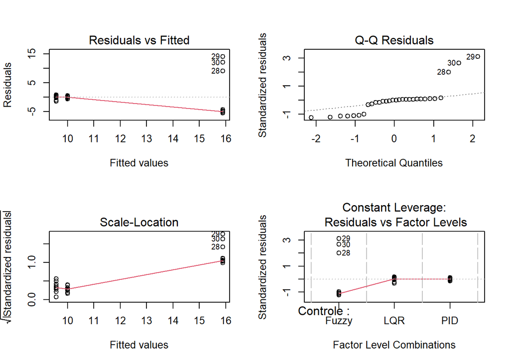

```r
par(mfrow = c(2, 2))
plot(modelo)
```

Já o **gráfico Q-Q Plot** mostra que os resíduos **não seguem uma distribuição normal**: os pontos esperados se afastam significativamente da linha teórica nos extremos, novamente devido aos outliers no grupo Fuzzy, o que configura uma clara violação da normalidade dos resíduos.

O **gráfico Scale-Location** reforça a heterocedasticidade, pois evidencia que a variabilidade dos resíduos aumenta com os valores ajustados. A linha crescente sugere que as **variâncias não são constantes ao longo dos grupos**, invalidando outro pressuposto essencial da ANAVA.

Por fim, o **gráfico Resíduos vs Níveis do Fator (Tipo de Controle)** mostra que os maiores resíduos ocorrem exclusivamente no grupo Fuzzy, com valores **altamente discrepantes em relação aos demais níveis**. Essa distorção compromete a comparação entre os grupos e pode enviesar os resultados da análise.

Diante dessas evidências, conclui-se que as premissas básicas da ANAVA não foram atendidas, comprometendo a validade da análise estatística. Como alternativas, pode-se aplicar transformações nos dados, como logaritmo ou raiz quadrada, visando estabilizar as variâncias e aproximar os resíduos da normalidade. Outra solução viável seria adotar métodos robustos ou não paramétricos, como o teste de Kruskal-Wallis, que não pressupõe normalidade nem homogeneidade de variância. Além disso, é recomendável realizar análises com e sem os outliers, comparando os resultados e justificando a abordagem escolhida com base no contexto do experimento.

## 2.4 Testes Complementares

A análise dos pressupostos da ANAVA foi complementada com dois testes estatísticos: o **Shapiro-Wilk** para normalidade dos resíduos e o **Bartlett** para homogeneidade das variâncias. Ambos os testes retornaram valores de **p extremamente baixos (p < 0,01)**, indicando que os pressupostos fundamentais da ANAVA **não foram atendidos** neste conjunto de dados.

O **teste de Shapiro-Wilk** foi utilizado para verificar se os resíduos do modelo seguem uma distribuição normal, como exige a ANAVA clássica. O valor de W = 0,75428 com um **p-valor de 1.069e-05** indica uma forte evidência contra a normalidade dos resíduos. Isso significa que os dados apresentam uma distribuição distorcida, provavelmente influenciada pela presença de outliers, como já identificado nos gráficos de diagnóstico.

Já o **teste de Bartlett** foi empregado para verificar a **homogeneidade das variâncias** entre os grupos (PID, LQR e Fuzzy). O resultado, com **p-valor = 2.012e-14**, indica que as variâncias são significativamente diferentes entre os grupos. Ou seja, a suposição de variâncias iguais — essencial para a validade do teste F da ANAVA — foi violada.

Esses dois resultados confirmam que a aplicação direta da ANAVA não é apropriada neste caso. Como alternativa, recomenda-se aplicar **transformações nos dados** (como logaritmo ou raiz quadrada), ou empregar testes **não paramétricos**, como o **Kruskal-Wallis**, que são mais robustos a essas violações.

```r
shapiro.test(residuals(modelo))  # Teste de normalidade
```

```
##
##  Shapiro-Wilk normality test
##
## data:  residuals(modelo)
## W = 0.75428, p-value = 1.069e-05
```

```r
bartlett.test(Tempo ~ Controle, data = dados)  # Homogeneidade de variâncias
```

```
##
##  Bartlett test of homogeneity of variances
##
## data:  Tempo by Controle
## Bartlett's K-squared = 63.074, df = 2, p-value = 2.012e-14
```

```r
# Criar dataframe do teste de Shapiro-Wilk
shapiro_df <- data.frame(
  Estatística = "W",
  Valor = 0.75428,
  `p-valor` = 1.069e-05
)

# Exibir tabela formatada
shapiro_df |>
  gt() |>
  tab_header(
    title = md("**Tabela - Teste de Normalidade (Shapiro-Wilk)**")
  ) |>
  tab_style(
    style = list(cell_text(weight = "bold", color = "white"),
                 cell_fill(color = "black")),
    locations = cells_column_labels()
  ) |>
  tab_style(
    style = cell_text(align = "center"),
    locations = cells_body(columns = everything())
  ) |>
  fmt_number(
    columns = where(is.numeric),
    decimals = 5,
    use_seps = FALSE
  )
```

**Tabela - Teste de Normalidade (Shapiro-Wilk)**

| Estatística | Valor | p.valor |
| --- | --- | --- |
| W | 0.75428 | 0.00001 |

## 2.5 Solução: Teste de Kruskal-Wallis

A ANAVA não paramétrica de Kruskal-Wallis é uma alternativa à ANOVA tradicional quando os pressupostos desta não são atendidos, especialmente a normalidade dos resíduos e a homogeneidade de variâncias. Ao contrário da ANOVA clássica, o teste de Kruskal-Wallis não exige que os dados sigam uma distribuição normal, o que o torna adequado para dados assimétricos ou com distribuição desconhecida.

Outro ponto forte do teste de Kruskal-Wallis é sua robustez a outliers. Como ele trabalha com ranks (posições ordenadas dos valores) em vez dos próprios valores numéricos, os efeitos de observações extremas são minimizados, reduzindo seu impacto nos resultados da análise.

Se o valor-p for menor que o nível de significância adotado (por exemplo, 0,05), podemos concluir que há pelo menos um grupo com mediana significativamente diferente dos demais.

```r
kruskal.test(Tempo ~ Controle, data = dados)
```

```
##
##  Kruskal-Wallis rank sum test
##
## data:  Tempo by Controle
## Kruskal-Wallis chi-squared = 18.661, df = 2, p-value = 8.869e-05
```

## 2.6 BoxPlot

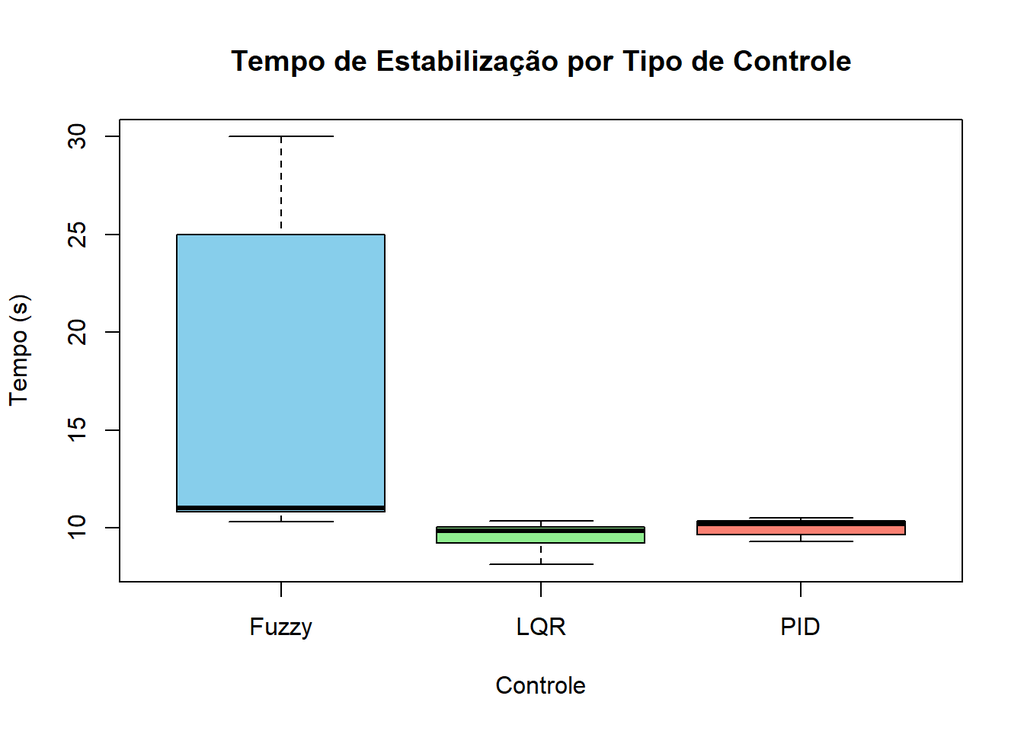

```r
boxplot(Tempo ~ Controle, data = dados,
        col = c("skyblue", "lightgreen", "salmon"),
        main = "Tempo de Estabilização por Tipo de Controle",
        ylab = "Tempo (s)")
```

# 3 Conclusão

Este relatório demonstrou, com base em um experimento simulado, como a presença de outliers pode comprometer os pressupostos fundamentais da ANAVA tradicional. Os testes formais de normalidade (Shapiro-Wilk) e homogeneidade de variâncias (Bartlett) revelaram violações significativas, reforçadas pelas análises gráficas dos resíduos. Tais violações invalidam a aplicação do teste F da ANAVA, podendo levar a conclusões incorretas sobre a influência do fator estudado.

Como alternativa metodológica, foi aplicada a ANAVA não paramétrica de Kruskal-Wallis, que não exige normalidade nem igualdade de variâncias. Este teste confirmou a existência de diferenças estatisticamente significativas entre os grupos, mesmo diante dos valores extremos. Por sua natureza robusta, o teste de Kruskal-Wallis mostrou-se mais adequado para analisar os dados simulados neste estudo.

Concluímos, portanto, que a validação dos pressupostos da ANAVA é uma etapa crítica na análise de experimentos. Em casos de violação, recomenda-se o uso de transformações ou métodos estatísticos robustos, como testes não paramétricos, para garantir que as inferências realizadas sejam confiáveis e representem com fidelidade os fenômenos observados.

# 4 Código

**Código**

```
# Carregar bibliotecas
library(gt)
library(dplyr)

# Gerar os dados
set.seed(456)
Controle <- rep(c("PID", "LQR", "Fuzzy"), each = 10)

Tempo <- c(
  rnorm(10, mean = 10, sd = 0.5),        # PID
  rnorm(10, mean = 9, sd = 0.6),         # LQR
  c(rnorm(7, mean = 11, sd = 0.4), 25, 30, 28)  # Fuzzy com outliers
)

dados <- data.frame(Controle, Tempo)

# Exibir tabela formatada
dados |>
  gt() |>
  tab_style(
    style = list(cell_text(weight = "bold", color = "white"),
                 cell_fill(color = "black")),
    locations = cells_column_labels()
  ) |>
  tab_style(
    style = cell_text(align = "center"),
    locations = cells_body(columns = everything())
  ) |>
  data_color(
    columns = everything(),
    rows = seq(1, 10, 1),
    palette = "#f2f2f2"
  ) |>
  data_color(
    columns = everything(),
    rows = seq(11, 20, 1),
    palette = "#FFB2B2"
  ) |>
  data_color(
    columns = everything(),
    rows = seq(21, 30, 1),
    palette = "#f2f2f2"
  )
modelo <- aov(Tempo ~ Controle, data = dados)
summary(modelo)

# Converter resultado ANOVA para data frame
anova_df <- summary(modelo)[[1]] |>
  tibble::rownames_to_column("Fonte de Variação") |>
  rename(
    `GL` = Df,
    `SQ` = `Sum Sq`,
    `QM` = `Mean Sq`,
    `Valor-F` = `F value`,
    `Pr(>F)` = `Pr(>F)`
  )

# Exibir tabela ANOVA com formatação
anova_df |>
  gt() |>
  tab_header(
    title = md("**Tabela - ANOVA do Modelo**")
  ) |>
  tab_style(
    style = list(cell_text(weight = "bold", color = "white"),
                 cell_fill(color = "black")),
    locations = cells_column_labels()
  ) |>
  tab_style(
    style = cell_text(align = "center"),
    locations = cells_body(columns = everything())
  ) |>
  fmt_number(
    columns = where(is.numeric),
    decimals = 3
  )
par(mfrow = c(2, 2))
plot(modelo)

shapiro.test(residuals(modelo))  # Teste de normalidade
bartlett.test(Tempo ~ Controle, data = dados)  # Homogeneidade de variâncias

# Criar dataframe do teste de Shapiro-Wilk
shapiro_df <- data.frame(
  Estatística = "W",
  Valor = 0.75428,
  `p-valor` = 1.069e-05
)

# Exibir tabela formatada
shapiro_df |>
  gt() |>
  tab_header(
    title = md("**Tabela - Teste de Normalidade (Shapiro-Wilk)**")
  ) |>
  tab_style(
    style = list(cell_text(weight = "bold", color = "white"),
                 cell_fill(color = "black")),
    locations = cells_column_labels()
  ) |>
  tab_style(
    style = cell_text(align = "center"),
    locations = cells_body(columns = everything())
  ) |>
  fmt_number(
    columns = where(is.numeric),
    decimals = 5,
    use_seps = FALSE
  )

kruskal.test(Tempo ~ Controle, data = dados)

boxplot(Tempo ~ Controle, data = dados,
        col = c("skyblue", "lightgreen", "salmon"),
        main = "Tempo de Estabilização por Tipo de Controle",
        ylab = "Tempo (s)")
```